# O medo da morte altera os termos da polarização política?

Consequências políticas da pandemia da Covid-19 no Brasil

Carlos Pereira (FGV/EBAPE)

Amanda Medeiros (FGV/EBAPE)

Frederico Bertholini (UnB/IPOL)

Abril, 2020

“Quem é você?  
Eu sou a morte.  
Você veio me buscar?  
Eu tenho acompanhado você há muito tempo…  
Eu sei.  
Você está preparado?  
Meu corpo está, mas eu não estou. Espere um instante.  
Todos vocês dizem isso, mas não há trégua.”  
O Sétimo Selo,  
Ingmar Bergman (1956)

# Questões de interesse

Choque Exógeno: COVID-19  
- Altera o eixo da polarização? (isolamento social)

Ideologia

Bolsonaro > consequências econômicas  
vs.  
Governadores > riscos à saúde

Pertencimento de grupo

In-group > contra o isolamento  
vs.  
Out-group > a favor do isolamento

# Governando com o “povo”: uma aproximação populista ao modelo de coalizão

- In-group vs. out-group
- Povo vs. elites (e as coalizões)
- Blame shifting como estratégia de comunicação populista

# Metodologia

- Pesquisa de opinião, entre 28.mar e 04.abr. Distribuição: redes sociais.
- n = 7.848 (8.168 pré limpeza)
1. opinião sobre isolamento social; prejuízos financeiros para sua atividade; iii) as medidas de isolamento que haviam sido implementadas pelo governo; iv) se conheciam alguém infectado pela Covid-19;
2. quem acreditavam ser a autoridade responsável pelo controle da pandemia;
3. como avaliavam as ações de governadores e Presidente;
4. o grau de concordância com a política de isolamento e por quanto estariam dispostos a ficar isolados;
5. aspectos sócio demográficos.

# Novos eixos da polarização ideológica

- Consenso do Centro à Esquerda: a favor do isolamento e contra as ações do Presidente.
- A direita, porém, está dividida!

## Avaliação sobre o isolamento por ideologia

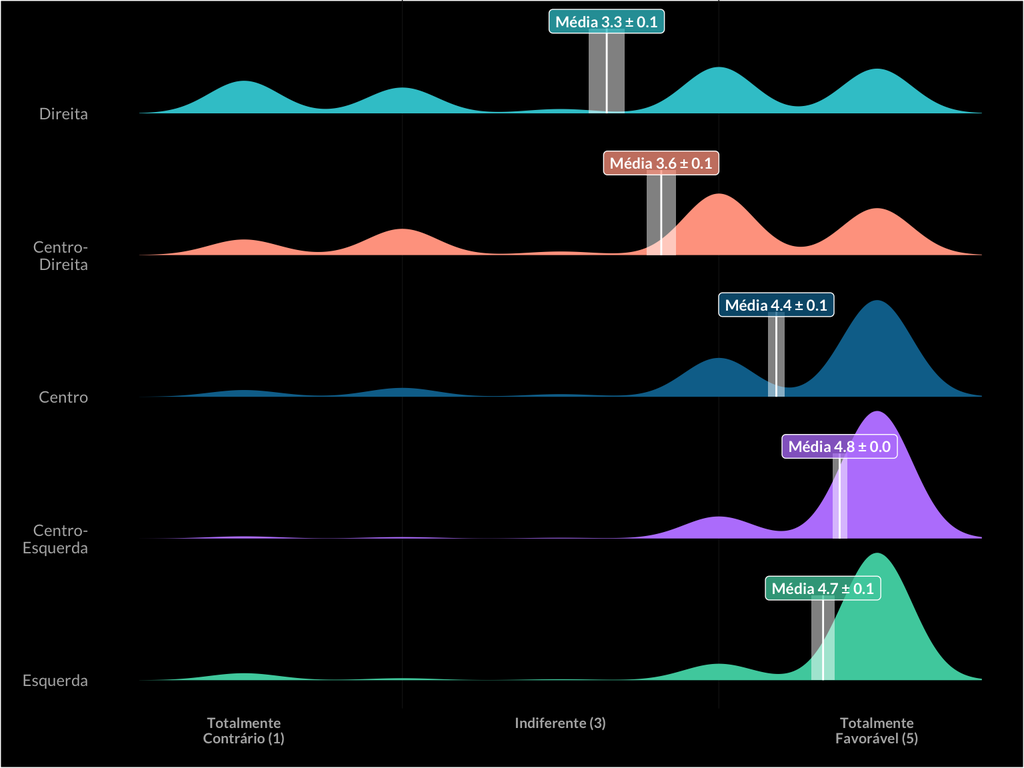

## Avaliação sobre o tempo de isolamento por ideologia

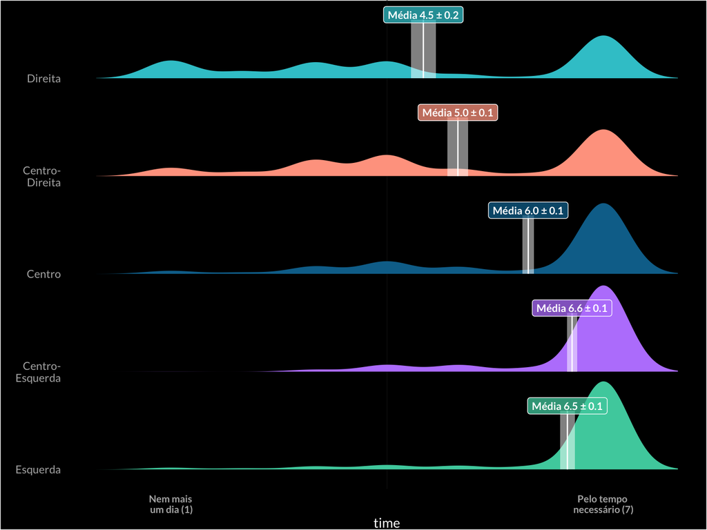

## Avaliação sobre as ações do Presidente

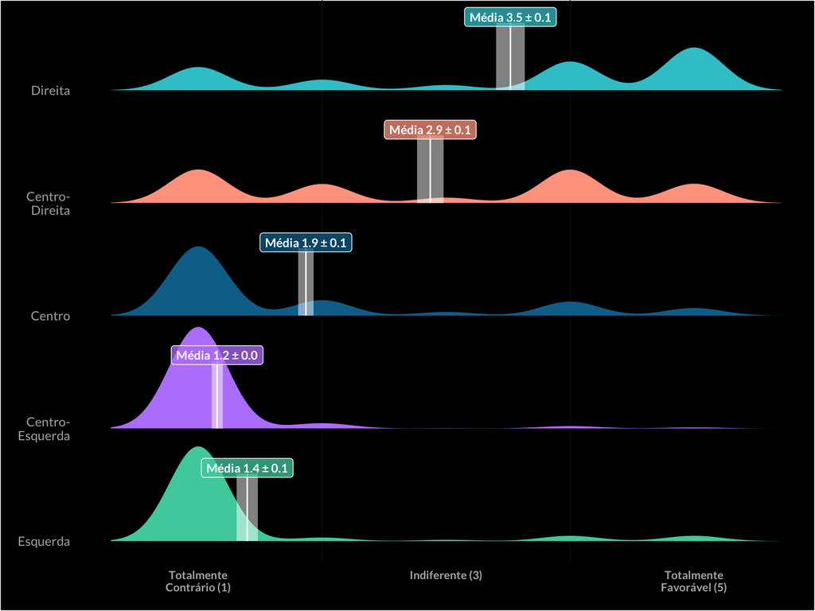

## Avaliação sobre as ações dos Governadores

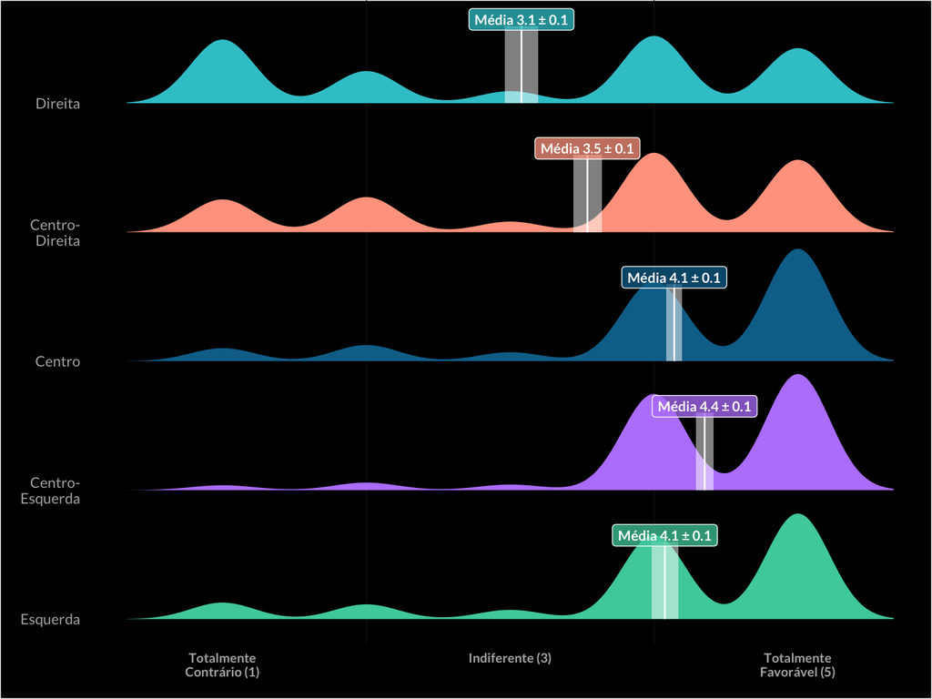

## Isolamento é coisa de rico?

- Diferença entre preferência por isolamento e possibilidade de realizá-lo.

## Preferência pelo isolamento por faixas de renda

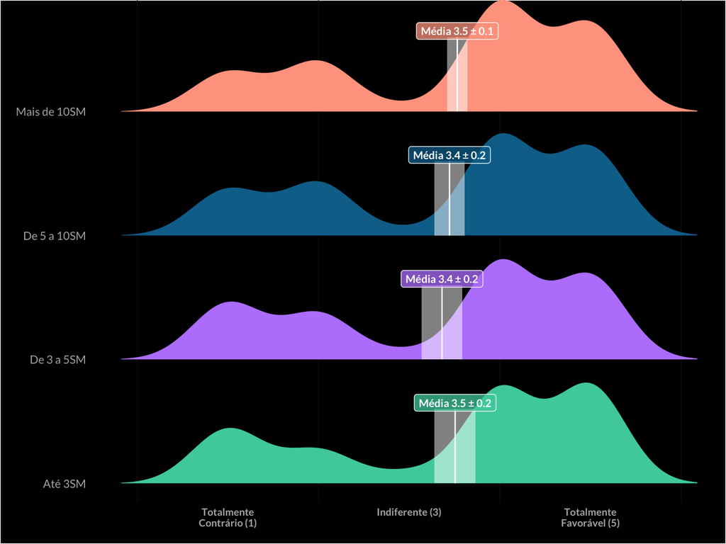

# O que explica esse comportamento?

# O espectro da morte

- À medida que os indivíduos tomam conhecimento de vítimas fatais em seu convívio próximo, as coisas começam a mudar.
- Ficam mais sensíveis ao isolamento, estão dispostos a praticarem por mais tempo.
- Avaliam pior o Presidente e melhor os Governadores.

## Avaliação sobre o isolamento

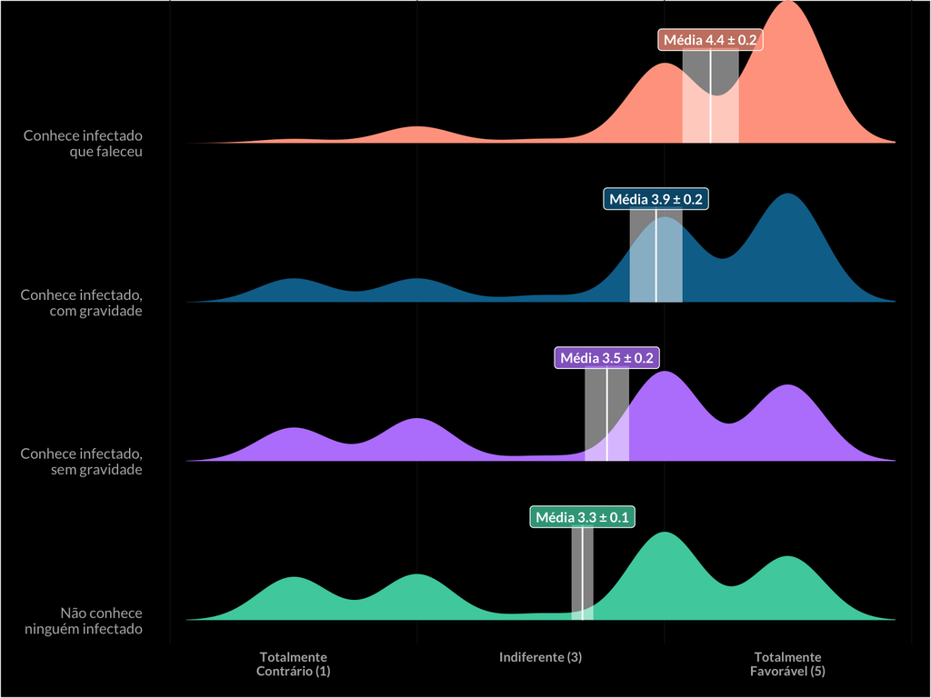

## Avaliação sobre o tempo de isolamento

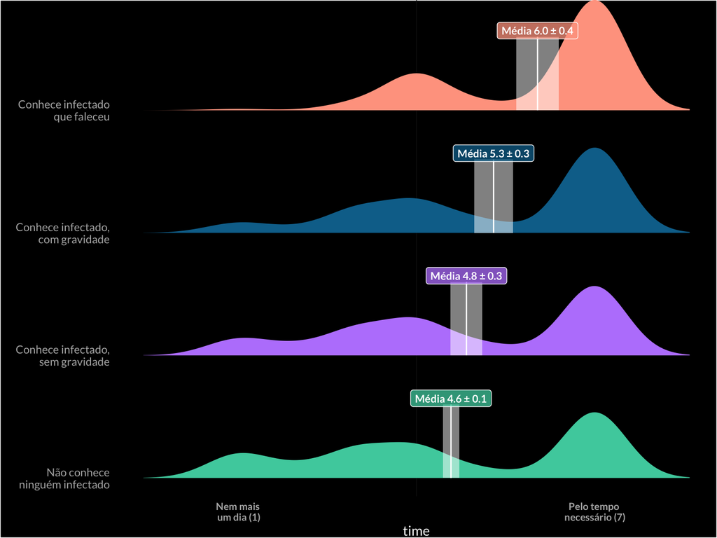

## Avaliação sobre as ações do Presidente

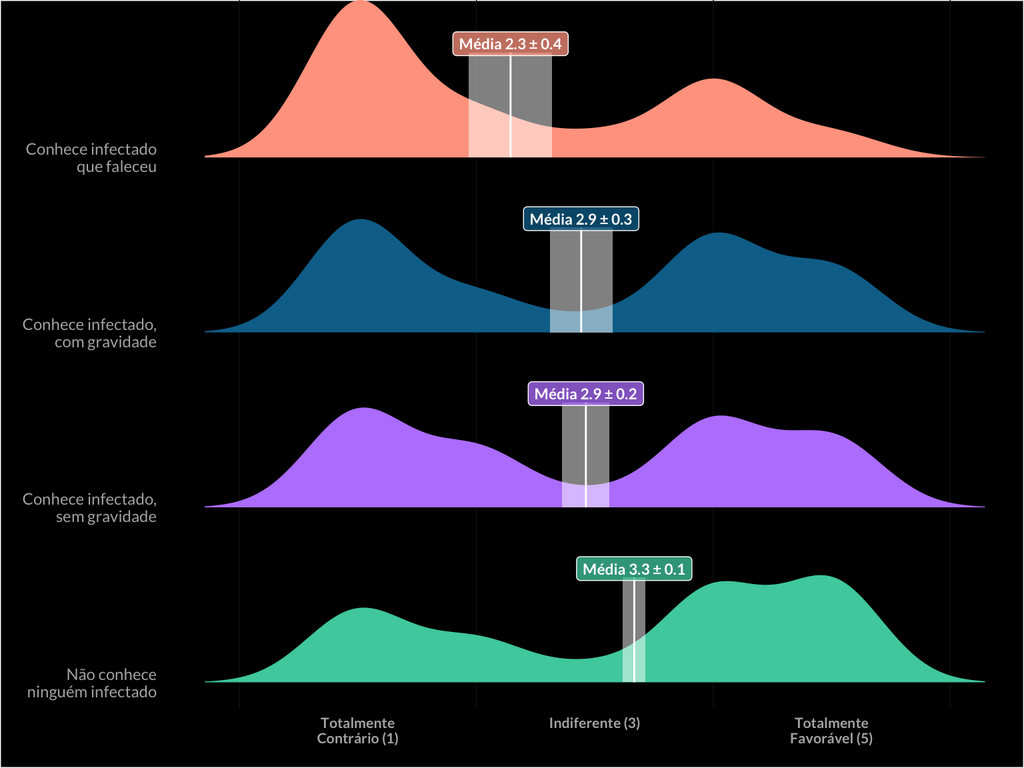

## Avaliação sobre as ações dos Governadores

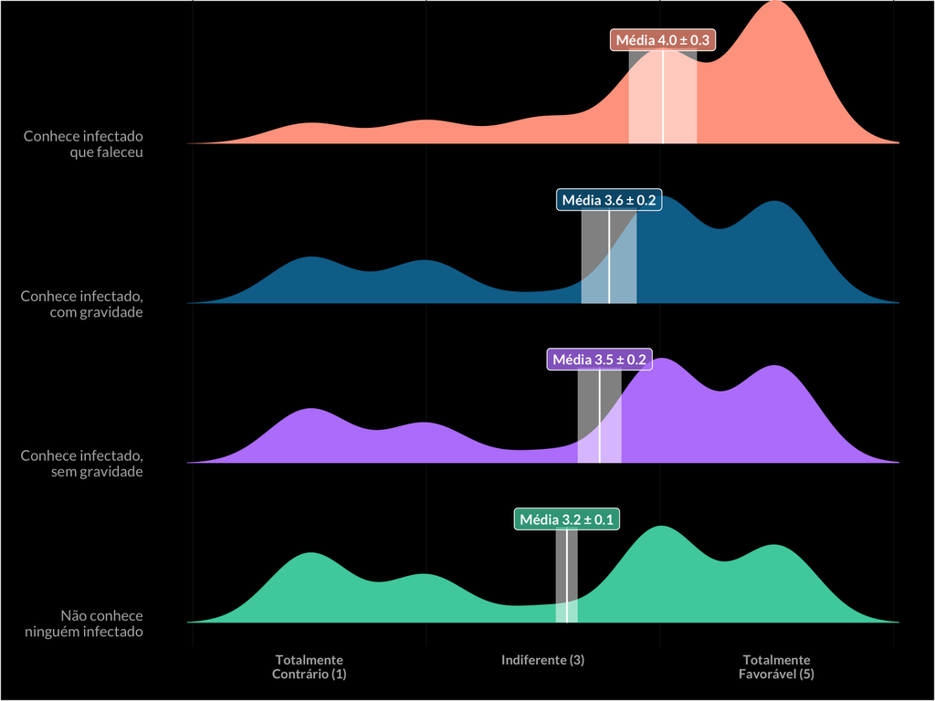

## Isolamento pode não ser coisa de rico, mas…

- Quem acredita que terá muito prejuízo é menos aderente ao isolamento.
- Renda não tem relevância, mas o prejuízo econômico esperado, sim.
- Diferença entre preferência por isolamento e possibilidade de realizá-lo.

## Preferência pelo isolamento por faixas de renda

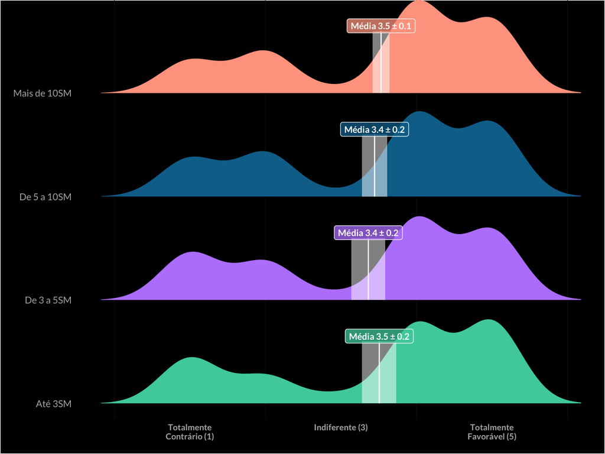

## Preferência pelo isolamento por prejuízo econômico

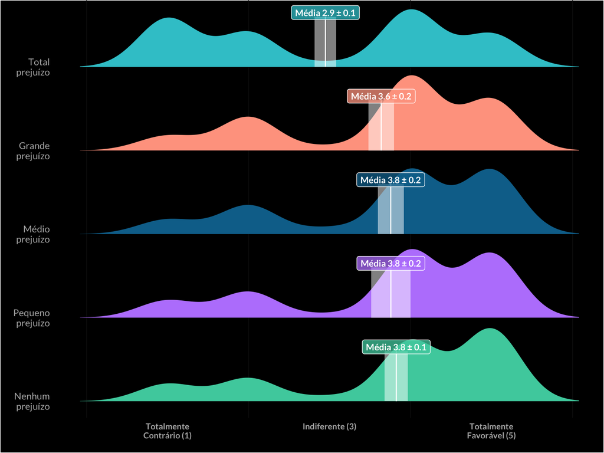

# Uma escolha difícil?

Neste novo eixo de polarização, a exposição à morte importa.

- Tanto no isolamento
- Quanto na posição em relação aos políticos

O medo da morte é tão grande que relativiza as outras dimensões

Como se relacionam opiniões sobre isolamento, prejuízo econômico e proximidade com pessoas afetadas pela doença?

## Concordância com Isolamento

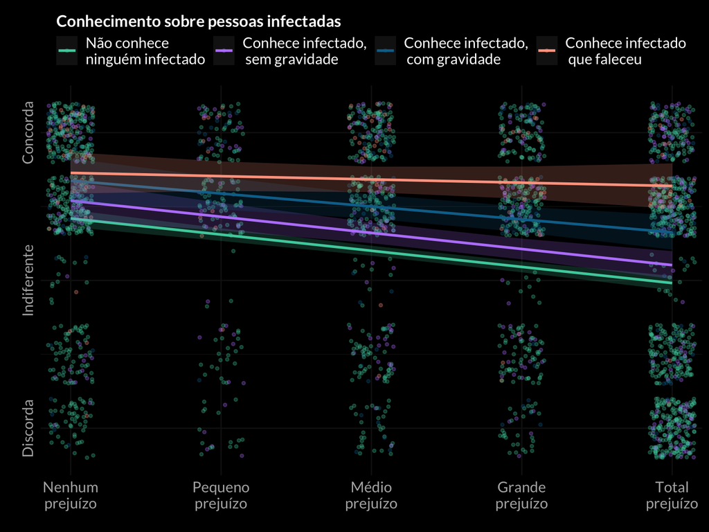

## Concordância com as ações do Presidente

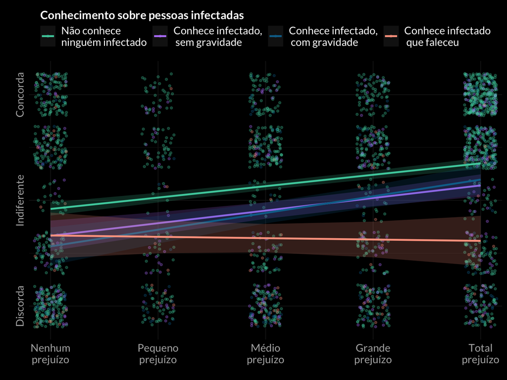

## Estimações do apoio ao isolamento por prejuízo econômico e exposição aos efeitos da Covid-19

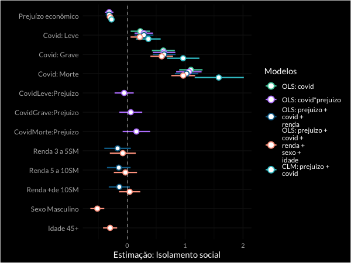

# Discussão

1. Lideranças que sinalizam esforço para combater a pandemia podem extrair maiores benefícios políicos do que aquelas mais precupadas em evitar deterioração econômica.
2. A direita se dividiu, porém não é uma questão de renda, a divisão diminui à medida que o risco de morte se torna algo mais palpável.

## Quem continua apoiando Bolsonaro?